# SOARS Tutorial– htmlWidgets

3/8/2017

## Example data

```r
load("data/co_floods.Rdata")
colnames(co_floods)
```

```
##  [1] "begin_date"        "end_date"          "event_type"
##  [4] "fips"              "cz_name"           "deaths_direct"
##  [7] "injuries_direct"   "damage_property"   "damage_crops"
## [10] "source"            "begin_lat"         "begin_lon"
## [13] "end_lat"           "end_lon"           "flood_cause"
## [16] "episode_narrative" "event_narrative"
```

```r
co_floods %>% select(event_type, cz_name, fips) %>% slice(1:3)
```

```
## # A tibble: 3 × 3
##    event_type cz_name  fips
##         <chr>   <chr> <dbl>
## 1 Flash Flood Fremont  8043
## 2       Flood  Pueblo  8101
## 3       Flood  Pueblo  8101
```

## Example data

```r
co_floods %>% select(begin_date, event_narrative) %>% sample_n(4) %>%
  pander(split.cells = c(5, 50))
```

| begin_date | event_narrative |
| --- | --- |
| 2015-05-08 | Flooding and flash flooding washed out several county roads including: CR73 from CR112 to CR98; Freese Road from Colorado 86 to CR112; CR102, from Double Tree Ranch to the top of the Bluff; CR9 betwee… |
| 2014-07-15 | The Arkansas River at La Junta briefly went above flood stage causing minor agricultural flooding. |
| 2013-08-10 |  |
| 2014-07-29 | North and northwest of Wellington, flash flooding produced extensive field flooding. Flash flooding forced the closure of Rawhide Flats Road with extensive field flooding due to standing water on coun… |

## Mapping Colorado floods

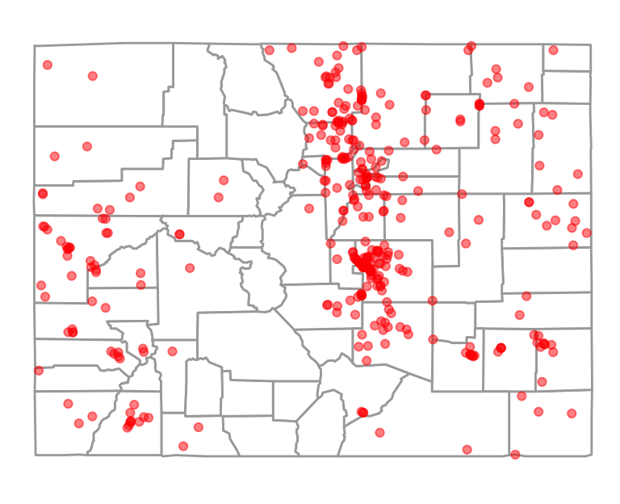

```r
library(ggplot2)
map_data("county", region = "colorado") %>%
  ggplot(aes(x = long, y = lat, group = group)) +
  geom_polygon(color = "darkgray", fill = "white") +
  geom_point(data = co_floods, aes(x = begin_lon, y = begin_lat, group = NULL),
             color = "red", alpha = 0.5) +
  coord_map() + theme_void()
```

## Mapping Colorado floods and tornadoes

[interactive chart not shown]

## Creating a basic leaflet map

The three basic components of a leaflet map are:

- Leaflet widget
- Background (tiles)
- Mapping of data to locations

```r
co_floods %>% leaflet() %>%
  addProviderTiles("OpenStreetMap.Mapnik") %>%
  addCircleMarkers(lng = ~ begin_lon, lat = ~begin_lat, radius = 3, color = "blue")
```

[interactive chart not shown]

## Choices for map tiles

With `addProviderTiles`, you can pick from many different background map tiles. Visit [this provider preview page](https://leaflet-extras.github.io/leaflet-providers/preview/) to see options and get the provider names to use in the R call. Here is the same map using different map tiles:

```r
co_floods %>% leaflet() %>%
  addProviderTiles("NASAGIBS.ViirsEarthAtNight2012") %>%
  addProviderTiles("CartoDB.DarkMatterOnlyLabels") %>%
  addCircleMarkers(lng = ~ begin_lon, lat = ~begin_lat, radius = 3, color = "green")
```

[interactive chart not shown]

## Choices for mapping data to locations

There are various things you can add to the map to map data to locations. Several are listed here, and all can be add using `add` plus the item name (for example, `addMarkers`).

- `Markers`: "Push pin" style markers
- `CircleMarkers`: The circle markers shown in examples so far
- `LabelOnlyMarkers`
- `Polylines`
- `Circles`
- `Rectangles`
- `Polygons`

You can layer several of these on the same leaflet map (e.g., roads with `Polylines`, counties with `Polygons`, exact locations with one of the markers).

## Choices for mapping data to locations

Data can be mapped from a dataframe with columns for longitude and latitude. In this case, the names of the correct columns for longitude and latitude should be specified with the `lng` and `lat` arguments:

```r
leaflet() %>%
  addProviderTiles("OpenStreetMap.Mapnik") %>%
  addCircleMarkers(data = co_floods, lng = ~ begin_lon, ~ begin_lat,
                   radius = 3, color = "blue") %>%
  addMarkers(data = co_tornadoes, lng = ~ begin_lon, ~ begin_lat)
```

[interactive chart not shown]

## Choices for mapping data to locations

Alternatively, if you have data saved as a spatial object, you can map that directly without specifying latitude and longitude columns.

The [`tigris` package](https://github.com/walkerke/tigris) allows you to pull US Census TIGER shapefiles directly from R. The following call pulls a shape file with Colorado county boundaries (the `cb` options is so we pull a lower-resolution version):

```r
library(tigris)
co_counties <- counties(state = 'CO', cb = TRUE)
class(co_counties)
```

```
## [1] "SpatialPolygonsDataFrame"
## attr(,"package")
## [1] "sp"
```

## Choices for mapping data to locations

This spatial object can be used when mapping data to location with the `data` option:

```r
leaflet() %>%
  addProviderTiles("Stamen.TonerBackground") %>%
  addPolygons(data = co_counties) %>%
  addCircleMarkers(data = co_floods, lng = ~ begin_lon, ~ begin_lat,
                   radius = 3, color = "green")
```

[interactive chart not shown]

## Customizing icons

You can use a custom icon for the map markers. For example, [this tornado icon](https://thenounproject.com/term/tornado/11563/) was created by Gilad Fried and is under a Creative Commons license. You can use the following code to use it to mark the Colorado tornados (this assumes it's been saved locally as "figures/tornado.png"):

```r
co_tornadoes %>%
  leaflet() %>% addProviderTiles("OpenStreetMap.Mapnik") %>%
  addMarkers(~ begin_lon, ~ begin_lat,
             icon = makeIcon("figures/tornado.png", iconWidth = 20, iconHeight = 20))
```

[interactive chart not shown]

## Using cluster markers

In cases where a leaflet map has a lot of points, it can be hard to interpret until you zoom in. In this case, it often helps to use `markerClusterOptions()` to create cluster markers until the map is zoomed in.

```r
leaflet() %>%
  addProviderTiles("OpenStreetMap.Mapnik") %>%
  addCircleMarkers(data = co_floods, lng = ~ begin_lon, ~ begin_lat,
                   radius = 3, color = "blue",
                   clusterOptions = markerClusterOptions())
```

[interactive chart not shown]

## Adding pop-ups

For any of these data mappings, you can add "pop-ups" to show information when a person clicks on a marker or shape. To do this, specify either a column from the dataframe you're mapping or a vector of the same length for the `popup` option. For example, the following call uses the beginning date of each flood in the pop-ups:

```r
leaflet() %>%
  addProviderTiles("OpenStreetMap.Mapnik") %>%
  addCircleMarkers(data = co_floods, lng = ~ begin_lon, ~ begin_lat, popup = ~ begin_date,
                   radius = 3, color = "green")
```

[interactive chart not shown]

## Adding pop-ups

Shape files will often include some information in the `data` slot that might be useful in a pop-up. For example, the `data` for `co_counties` includes county name:

```r
head(co_counties@data)
```

```
##     STATEFP COUNTYFP COUNTYNS       AFFGEOID GEOID        NAME LSAD
## 27       08      013 00198122 0500000US08013 08013     Boulder   06
## 28       08      029 00198130 0500000US08029 08029       Delta   06
## 29       08      059 00198145 0500000US08059 08059   Jefferson   06
## 30       08      091 00198161 0500000US08091 08091       Ouray   06
## 339      08      019 00198125 0500000US08019 08019 Clear Creek   06
## 340      08      023 00198127 0500000US08023 08023    Costilla   06
##          ALAND   AWATER
## 27  1881212055 36592000
## 28  2958007403 16886462
## 29  1979311263 25444831
## 30  1402657135  1599543
## 339 1023554877  3279667
## 340 3177806137  8828906
```

## Adding pop-ups

You can reference values in that `data` slot when mapping data to locations from data stored in a spatial object:

```r
leaflet() %>%
  addProviderTiles("Stamen.TonerBackground") %>%
  addPolygons(data = co_counties, popup = co_counties@data$NAME)
```

[interactive chart not shown]

## Adding pop-ups

Often, it can be helpful to paste together information from several columns of the dataframe to include in the pop-up:

```r
co_floods %>%
  leaflet() %>%
  addProviderTiles("OpenStreetMap.Mapnik") %>%
  addCircleMarkers(data = co_floods, lng = ~ begin_lon, ~ begin_lat,
                   popup = ~ paste("Date:", begin_date, "to", end_date),
                   radius = 3, color = "green")
```

[interactive chart not shown]

## Adding pop-ups

If you want to get even fancier, you can include HTML tags to style the text in the pop-ups:

```r
co_floods <- co_floods %>%
  mutate(popup_text = paste0("<div class='leaflet-popup-scrolled' style='max-height:150px'>",
                             "<b>County:  </b>", cz_name, "<br/>",
                             "<b>Dates:  </b>", begin_date, " to ", end_date, "<br/>",
                             "<b># deaths:  </b>", deaths_direct, "<br/>",
                             "<b># injuries:  </b>", injuries_direct, "<br/>",
                             "<b>Property damage:  </b>$", damage_property, "<br/>",
                             "<b>Crop damage:  </b>$", damage_crops, "<br/>",
                             event_narrative))
```

## Adding pop-ups

Here is the map using these fancier pop-ups:

```r
co_floods %>%
  leaflet() %>%
  addProviderTiles("OpenStreetMap.Mapnik") %>%
  addCircleMarkers(data = co_floods, lng = ~ begin_lon, ~ begin_lat, popup = ~ popup_text,
                   radius = 3, color = "green")
```

[interactive chart not shown]

## Setting the initial view

By default, the map will initial zoom to a point that bounds all the mappings. If you want to customize where and how much the map initially zooms, you can do that with `setView`. For example, this call sets the initial map to show the Fort Collins area rather than all of Colorado:

```r
co_floods %>%
  leaflet() %>% setView(lng = -105.0844, lat = 40.5853, zoom = 9) %>%
  addProviderTiles("OpenStreetMap.Mapnik") %>%
  addCircleMarkers(data = co_floods, lng = ~ begin_lon, ~ begin_lat, popup = ~ popup_text,
                   radius = 3, color = "blue")
```

[interactive chart not shown]

## Adding a minimap

If you set a tighter zoom like this, but also have data for a wider area, you may want to include a mini-map to help users navigate the map. You can do this with `addMinimap`:

```r
co_floods %>%
  leaflet() %>% setView(lng = -105.0844, lat = 40.5853, zoom = 9) %>%
  addMiniMap(position = "topright") %>%
  addProviderTiles("OpenStreetMap.Mapnik") %>%
  addCircleMarkers(data = co_floods, lng = ~ begin_lon, ~ begin_lat, popup = ~ popup_text,
                   radius = 3, color = "blue")
```

[interactive chart not shown]

## More widgets

- `htmlWidgets` gallery: http://gallery.htmlwidgets.org
- Make your own: http://www.htmlwidgets.org/develop_intro.html
- Find out more about the Javascript libraries: http://leafletjs.com/, https://plot.ly/javascript/
- Widgets within widgets (within widgets): http://seankross.com/2017/03/02/Mise-en-Abyme.html
- Interactive Periodic Table CV: http://www.masalmon.eu/2017/02/03/chemist/